# 🤱🏻 Hello World!

It's a pressing concern, pregnant women in vulnerable states, unborn babies, and a society split in between.

With the 2022 overturning of Roe v Wade in the US, tech companies have proudly announced the coverage of travel expenses for employees to receive continuous access to abortion e.g. [Reddit joining a NYT list with Google, Microsoft, Tesla, Uber & Co](https://cy.linkedin.com/posts/reddit-com_were-committed-to-helping-employees-receive-activity-6947599762871177216-LqlV?utm_source=li_share&utm_content=feedcontent&utm_medium=g_dt_web&utm_campaign=copy).

**As I don't know more, this notebook is my place to put down data and reflect.**

# 👩🏻‍💻 Looking at Data

#### ℹ️ About the Dataset

- Germany data only 🇩🇪
- As per [§15-18 Schwangerschaftskonfliktsgesetz (SchKG)](https://www.gesetze-im-internet.de/beratungsg/BJNR113980992.html#BJNR113980992BJNG000401307), abortion data is officially collected by the [The Federal Statistical Office](https://www.destatis.de/EN/About-Us/_node.html) - institutions conducting abortions are obliged to provide data
- Data is available since 1996, by calendar quarter, includes 7 characteristics, and only aggregated (further docu in the [quality report](https://www.destatis.de/DE/Methoden/Qualitaet/Qualitaetsberichte/Gesundheit/schwangerschaftsabbruch.pdf?__blob=publicationFile&v=3))

**In sum, it is a full dataset choosing §16 (1) SchKG characteristics 1. conduction of abortions 2. legal conditions for abortion (counseling regulation or according to indication) and 3. family status, age, and number of children of pregnant women.**

#### 🔎 Legal Conditions For Abortion

As per [§218 Strafgesetzbuch (StGB)](https://www.gesetze-im-internet.de/stgb/BJNR001270871.html#BJNR001270871BJNG005302307), abortions are part of the German criminal law under offences against life and incur a penalty of imprisonment or fine.

[§218a](https://www.gesetze-im-internet.de/stgb/__218a.html) excemptions are:

1. **counseling regulation:** when the pregnant woman requests the abortion and has sought counseling, the abortion is conducted by a physician, and no more than 12w have passed since conception
2. **medical indication:** when the health of the pregnant woman is endangered and the danger cannot be averted in any other reasonable way
3. **criminological indication:** when the pregnancy is consequence of rape or sexual abuse
4. like (1) with a 10w extension but only the pregnant woman does not incur penalty (meaning to go abroad) and if the pregnant woman was in exceptional distress at the time of the procedure

#### ⏭️ Just Some Lines Needed

```python
%load_ext autoreload
%autoreload 2
from utils.abortion_graphs import *
```

## 🙋🏻‍♀️ WDYT

- how many abortions have there been (past 10y, sized as city)
- what's the distribution vs newborns
- by reason (counseling, medical, criminological)
- by family status (single, married, divorced, widowed)
- by age group (<15-45+)
- by number of previous live births (0-5+)

## ❓ How many abortions have there been?

#### 🫱🏽 In the past 10y, abortions total 1mio with an average of 100k per year.

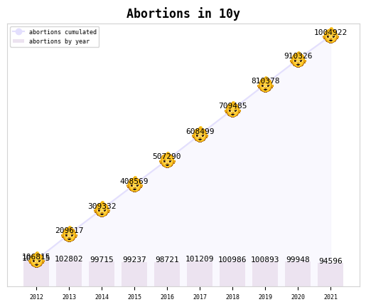

```python
years()
```

## ❓ If abortions were a city - which would they be sized like?

#### 🫱🏽 Abortions of the past 10y are as big as Cologne. Or, 68% of Munich, above half of Hamburg, less than a third of Berlin.

#### 🫱🏽 Every year, a city as Tübingen, Gießen, or any other marked in beige in between 90 and 111k inhabitants is aborted.

```python
cities()
```

Make this Notebook Trusted to load map: File -> Trust Notebook

[interactive chart not shown]

## ❓ How are abortions distributed?

#### 🫱🏽 Under all newborns, every 8.5th is aborted. For every 7.5 live births, there is 1 abortion.

#### 🫱🏽 Abortions are primarily 🗳️ based on counseling (96%), 👥 in single family status (57%), 👩 from women aged between 18 and 30 (50%), 🐣 and from women with no births before (40%).

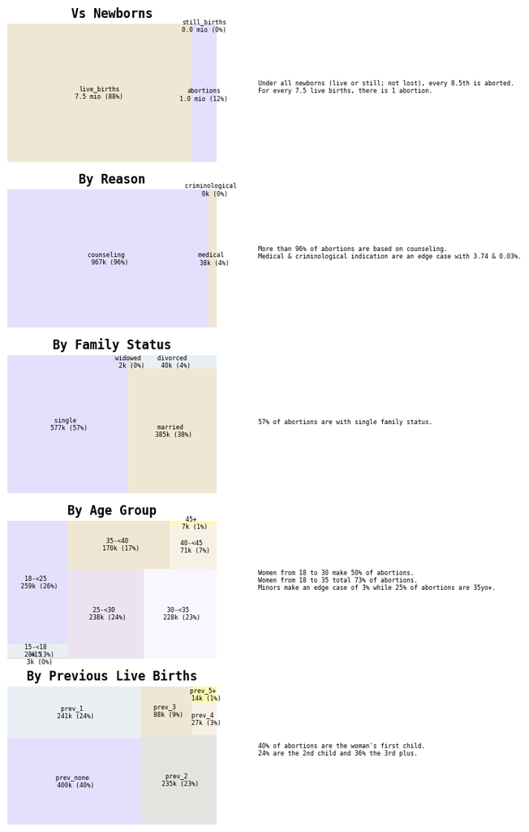

```python
treemaps()
```

# 🪐 Reflecting What It Means To Be Progressive

> 1 mio abortions in the past 10y, for every 7.5 live births one, <4% edge cases (medical, criminological; teen)

> 96% abortions requested with counseling, 57% in single family status, 50% 18-30yo, and 40% firstborn

*In the following I will plot my life against the past 10y of my own analysis since 2012. These are not pyplots anymore but a somewhat different set of data structured in the four parts secular, Jesus, German-Vietnamese, and blessed life.*

### 🌚 Secular Life

Being progressive to 17yo-me meant moving out for studies back in 2012. With 19 I could celebrate young, wild & free on a double degree in Mexico, go to the Amazon Munich office hangover after P1 when I was 20, and soju myself to oblivion at Seoul's #1 sky university at 23.

Early adoption, disruptive innovation, hype cycle, design sprint, scale-up, my business foundation is progressive. Then I progressed in the basics of technology. When we put 1 AND 1 together it gives 1 so there is XOR, one in my first lectures on logic gates. Putting male jumper wires into female breadboard holes, soldering together an arduino with modules, my first project with microcontrollers.

Being progressive gives freedom. The 96%, the 57%, the 50%, the 40%, that could have been me and I would have definitely hypothetically said yes to abortion. Birth control went back to high school when I recall the first girl in my class taking the "Antibabypille" as in German being a thing. And went on to talking fancy corporate egg-freezing at Meta and Apple over lunch as young professional later.

### 👼🏻 Jesus Life

When I read the Bible and turned Christian with 25, I was not a nun from the moon and if I became one now I'd be one with a pic with the tinder and 9gag co-founders from Bits & Pretzels 👩🏻‍🚀🔥

Christmas is that single point, that is that one birth, that to this day, defines the measurement of time and in that sense progressiveness. So "Hello Jesus!" to a 21st century jupyter notebook on his own birth!

When we look at the Bible, Mary did tick all the boxes, young adult, unmarried, firstborn, neither criminological nor medical indication, pregnant. And not having had sex, she did have doubts.

It was an angel speaking to her, she running to her cousin Elisabeth full of support, an angel speaking to Joseph who was about to leave, a group of shepherds running up in praise, two people at the temple showing wondering encouragement, and three wise men also bringing gifts. And their life did see dangers all around, traveling far when highly pregnant maybe early birth week 37 or late after 42, giving birth in a stable, fleeing after.

### 🪷 German-Vietnamese Life

My parents fled as well. It's my dad who told me what Vietnamese Buddhist monk Thích Nhất Hạnh taught the Vietnamese boat refugees on abortion. It's the same Thầy (teacher) nominated by Martin Luther King for the Nobel Peace Prize as "an apostle of peace and non-violence", invited to Google headquarters for mindfulness practices, and who also studied comparative religion at Princeton incl the theological seminary and lectured at Columbia.

It's not a decision by buddha but by the mother. And when the mother may think it through she may understand the pirate may not be educated and therefore capable to cause such suffering and she may feel compassion, forgive, and keep the child. When she cannot bear such compassion she may abort and bear the responsibility of killing, but it's her decision.

It's my mom who didn't have to abort but also she didn't have to have any children. She could have just stopped after 1, 2, 3, and later she did opt out after all.

### 🙏🏽 Blessed Life

So here I am, a young professional progressing from biblical generations over my Vietnamese parents to the high-tech world or the other way round.

Data and the holy spirit have become my logic gate, even studying protestant & islamic theology, the mastering of #Godengineering or believing of God as master engineer.

When we put 1 AND 1 together it gives 1, even though we can take other operations.

- I believe it needs a holy spirit to sometimes not take these other operations
- I believe we cannot come up with such a holy spirit ourselves so we need *the* holy spirit
- I believe we need people around us filled with the holy spirit same as around Mary
- I believe we can all be these people to someone around us

[output not shown]

### 🟰 What does it mean to be progressive?

967050 abortions in Germany's past 10y legally based on counseling

Maybe it's the other way round - not not having freedom and still choose abortion but having freedom and still choose life

Maybe it's the other way round - [SAP](https://www.linkedin.com/posts/cawa-younosi_sap-daretocare-health-activity-6947777052037029888-Wa9y?utm_source=linkedin_share&utm_medium=ios_app&trk=public_post_comment-text) and big tech covering safe births "hey we just want you to feel safe, here's some money and time off, you will not lose your job even though you give birth, whatever you will go through we take care and together manage"

Maybe in the end it's not either or but an and - data AND the holy spirit, maybe the most free and full of life progressive of progressiveness...

# 🖤 Thank you for reading.

Love & many blessings,  
Kim